# RNAseq_project

## Exploramos variables de interés para ver calidad.

```r
## Vemos la proporción de lecturas asignadas a genes.
rse_gene_SRP107565$assigned_gene_prob <- rse_gene_SRP107565$recount_qc.gene_fc_count_all.assigned/rse_gene_SRP107565$recount_qc.gene_fc_count_all.total
summary(rse_gene_SRP107565$assigned_gene_prob)
```

```
##    Min. 1st Qu.  Median    Mean 3rd Qu.    Max.
##  0.3544  0.6997  0.7218  0.7077  0.7395  0.7776
```

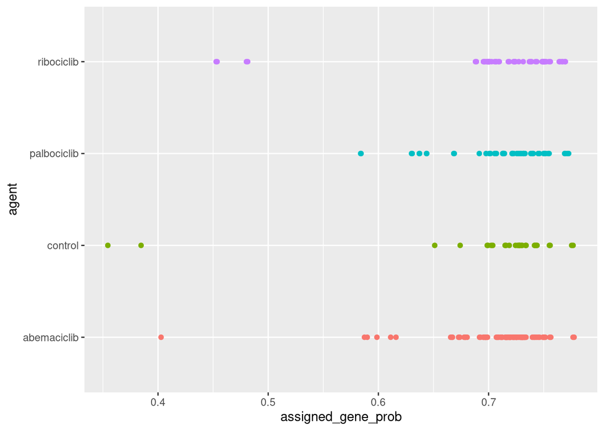

```r
library(ggplot2)
## Hacer un data.frame para graficar más fácil.
plot_df <- as.data.frame(colData(rse_gene_SRP107565)[
    ,
    grepl("^sra_attribute", colnames(colData(rse_gene_SRP107565)))
])

colnames(plot_df)<- c("agent", "cell_line", "dose", "source_name", "time")
plot_df$assigned_gene_prob <- rse_gene_SRP107565$assigned_gene_prob

## Vemos las diferencias entre los grupos de tratamiento con un scatter plot.
## Visualizamos
ggplot(data=plot_df, aes(x=assigned_gene_prob, y=agent, color=agent)) +
  geom_point() +
  theme(legend.position = "none")
```

```r
## Vemos la variación entre los grupos

with(colData(rse_gene_SRP107565), tapply(assigned_gene_prob, sra_attribute.agent, summary))
```

```
## $abemaciclib
##    Min. 1st Qu.  Median    Mean 3rd Qu.    Max.
##  0.4028  0.6974  0.7190  0.7078  0.7308  0.7776
##
## $control
##    Min. 1st Qu.  Median    Mean 3rd Qu.    Max.
##  0.3544  0.7034  0.7278  0.7005  0.7418  0.7767
##
## $palbociclib
##    Min. 1st Qu.  Median    Mean 3rd Qu.    Max.
##  0.5839  0.7014  0.7223  0.7119  0.7402  0.7727
##
## $ribociclib
##    Min. 1st Qu.  Median    Mean 3rd Qu.    Max.
##  0.4527  0.7001  0.7229  0.7072  0.7494  0.7697
```

Con la función summary vemos que en el grupo los tres grupos tienen la probabilidad de asociarse con genes muy similar, si bien el que tiene un promedio más bajo es ribociclib pero no por mucho (omitiendo el grupo control). Casi todos tienen una mediana muy similar, pero donde vemos las mejores proporciones es con las muestras con palbocilcib. En el grupo de palbociclib vemos que tienen un mínimo de 0.5839, el más alto de los otros dos grupos, así como el primer cuartil y también la media más alta.

## Limpieza de datos

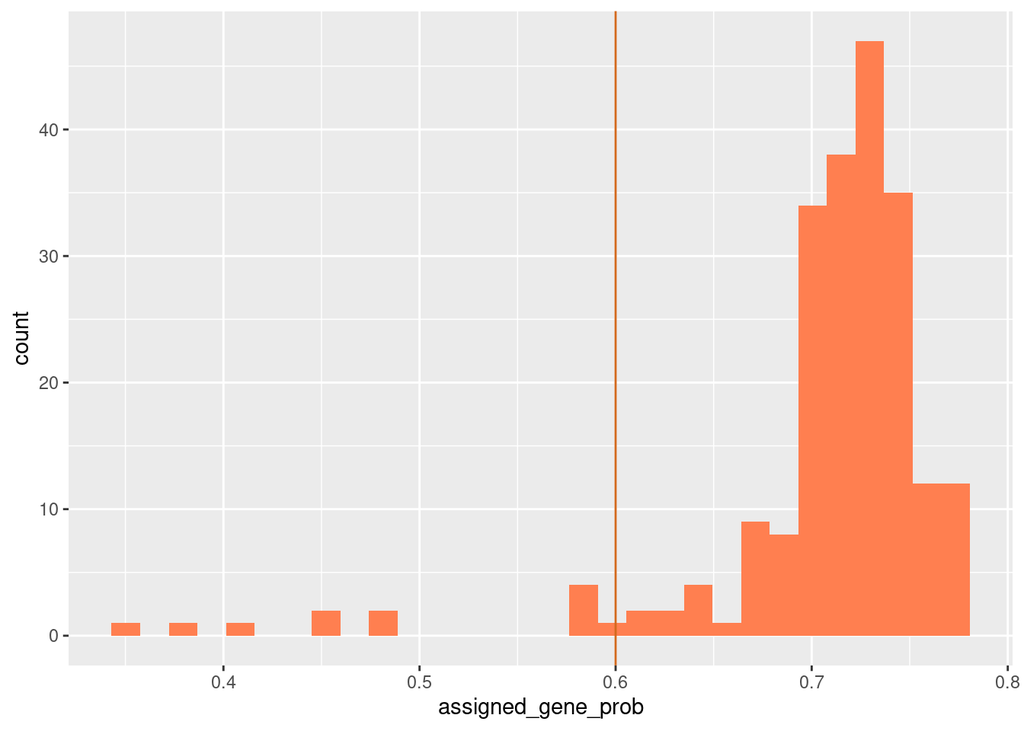

```r
## Guardamos los datos crudos
rse_gene_SRP107565_unfiltered <- rse_gene_SRP107565

## Visualizamos la calidad de las muestras
ggplot(data=plot_df, aes(x=assigned_gene_prob)) +
  geom_histogram(fill = "coral") +
  geom_vline(xintercept = 0.6, colour = "chocolate")
```

```r
## Quitamos las muestras que tengan proporción menor a 0.6
table(rse_gene_SRP107565$assigned_gene_prob < 0.6)
```

```
##
## FALSE  TRUE
##   204    12
```

```r
rse_gene_SRP107565 <- rse_gene_SRP107565[, rse_gene_SRP107565$assigned_gene_prob > 0.6]

## Para quitar las muestras que no tienen niveles de expresión significativos calculamos los niveles medios de expresión.
genes_prom <- rowMeans(assay(rse_gene_SRP107565, "counts"))
summary(genes_prom)
```

```
##     Min.  1st Qu.   Median     Mean  3rd Qu.     Max.
##     0.00     0.00     0.18    83.91    14.65 60507.06
```

```r
## Quitamos los genes que tengan niveles medios de expresión menores a uno.
rse_gene_SRP107565 <- rse_gene_SRP107565[genes_prom > 0.1, ]
dim(rse_gene_SRP107565)
```

```
## [1] 34554   204
```

```r
## Visualizamos el porcentaje de gens que retuvimos
round(nrow(rse_gene_SRP107565) / nrow(rse_gene_SRP107565_unfiltered) * 100, 2)
```

```
## [1] 54.11
```

Primeramente quitamos aquellas muestras que tenían una baja proporción de genes asignados. Vemos que en el histograma hay pocas muestras con una proporción baja, entonces podemos poner un umbral un poco alto de 0.6 para hacer un corte. Ahora limpiamos genes; quitamos los genes que tenían un valor de expresión menores a 0.1, puesto que habí muchos con valor de cero y tenemos dimensiones finales de 34,554 genes en nuestro objeto de summarized experiment.

# Normalización

Para poder hacer buenos estadísticos con nuestros datos hay que normalizarlos.

```r
## Hacemos el objeto que nos permite normalizar los datos de expresión
library("edgeR")
dge <- DGEList(
  counts = assay(rse_gene_SRP107565, "counts"),
  genes = rowData(rse_gene_SRP107565)
)

dge <- calcNormFactors(dge)
```

# Expresión diferencial

Exploramos de nuevo los datos que acabamos de limpiar. Separamos primero los datos con palbociclib, puesto a que es el que tenía más diferencias en la sección de exploración de variables, para que podamos ver cómo funciona la expresión entre las dos variables de tiempo que se reportaron (6 y 24 horas).

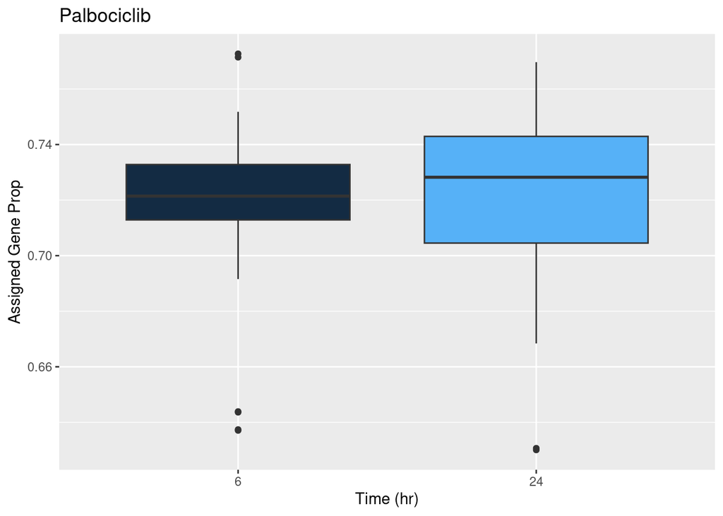

```r
## Separamos cada uno de los grupos a estudiar.
palbociclib <- rse_gene_SRP107565[,rse_gene_SRP107565$sra_attribute.agent == "palbociclib"]
#abemaciclib <- rse_gene_SRP107565[, rse_gene_SRP107565$sra_attribute.agent == "abemaciclib"]
#ribociclib <- rse_gene_SRP107565[, rse_gene_SRP107565$sra_attribute.agent == "ribociclib"]
control <- rse_gene_SRP107565[, rse_gene_SRP107565$sra_attribute.agent == "control"]

## Vemos las diferencias entre los los tiempos de acción en palbociclib.
ggplot(data=as.data.frame(colData(palbociclib)), aes(x=factor(sra_attribute.time), y=assigned_gene_prob)) +
  geom_boxplot(aes(fill = sra_attribute.time)) +
  theme(legend.position="none") +
  ylab("Assigned Gene Prop") +
  xlab("Time (hr)") +
  ggtitle("Palbociclib")
```

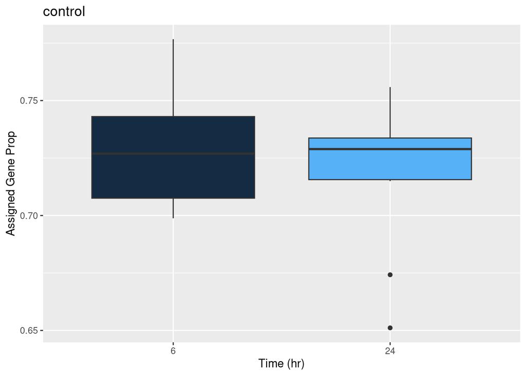

```r
## Vemos diferencias entre los tiempos de acción del control.
ggplot(data=as.data.frame(colData(control)), aes(x=factor(sra_attribute.time), y=assigned_gene_prob)) +
  geom_boxplot(aes(fill = sra_attribute.time)) +
  theme(legend.position="none") +
  ylab("Assigned Gene Prop") +
  xlab("Time (hr)") +
  ggtitle("control")
```

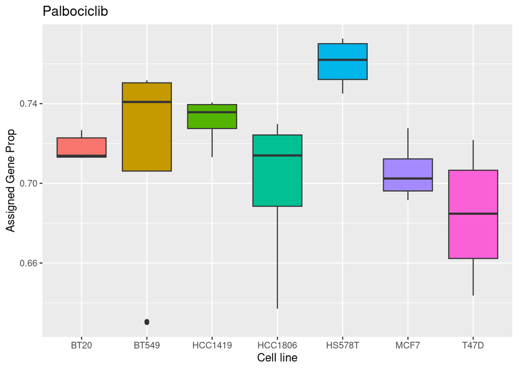

```r
## Vemos las diferencias entre líneas celulares y palbociclib
ggplot(data=as.data.frame(colData(palbociclib)), aes(x=sra_attribute.cell_line, y=assigned_gene_prob)) +
  geom_boxplot(aes(fill = sra_attribute.cell_line)) +
  theme(legend.position="none") +
  ylab("Assigned Gene Prop") +
  xlab("Cell line") +
  ggtitle("Palbociclib")
```

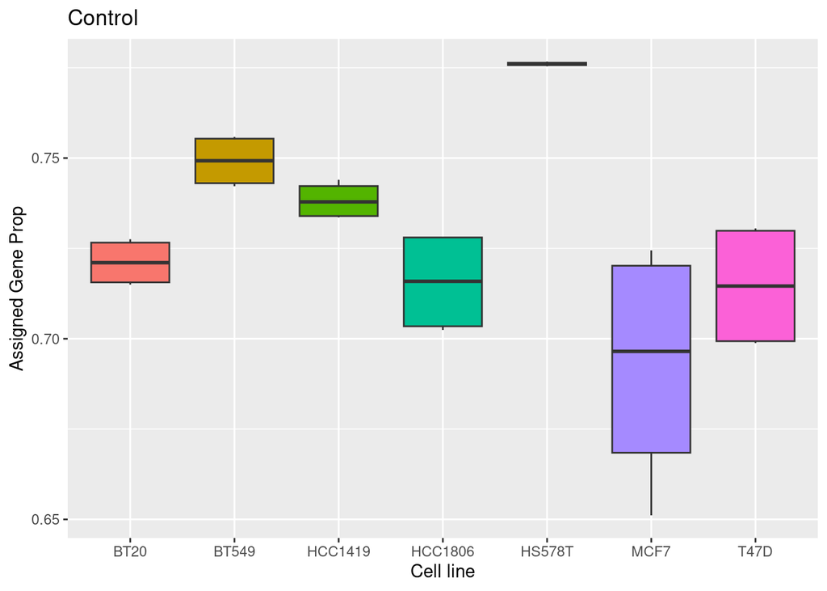

```r
## Ahora en el grupo control
ggplot(data=as.data.frame(colData(control)), aes(x=sra_attribute.cell_line, y=assigned_gene_prob)) +
  geom_boxplot(aes(fill = sra_attribute.cell_line)) +
  theme(legend.position="none") +
  ylab("Assigned Gene Prop") +
  xlab("Cell line") +
  ggtitle("Control")
```

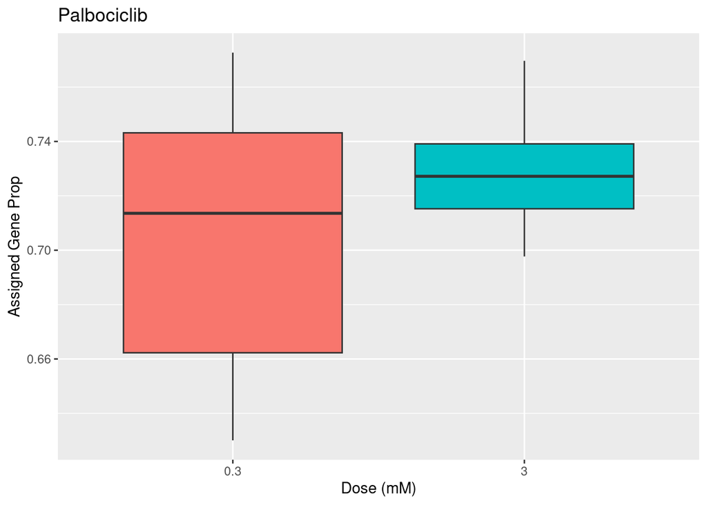

```r
## Por último comparamos por dosis en palbociclib
ggplot(data=as.data.frame(colData(palbociclib)), aes(x=factor(sra_attribute.dose), y=assigned_gene_prob)) +
  geom_boxplot(aes(fill = factor(sra_attribute.dose))) +
  theme(legend.position="none") +
  ylab("Assigned Gene Prop") +
  xlab("Dose (mM)") +
  ggtitle("Palbociclib")
```

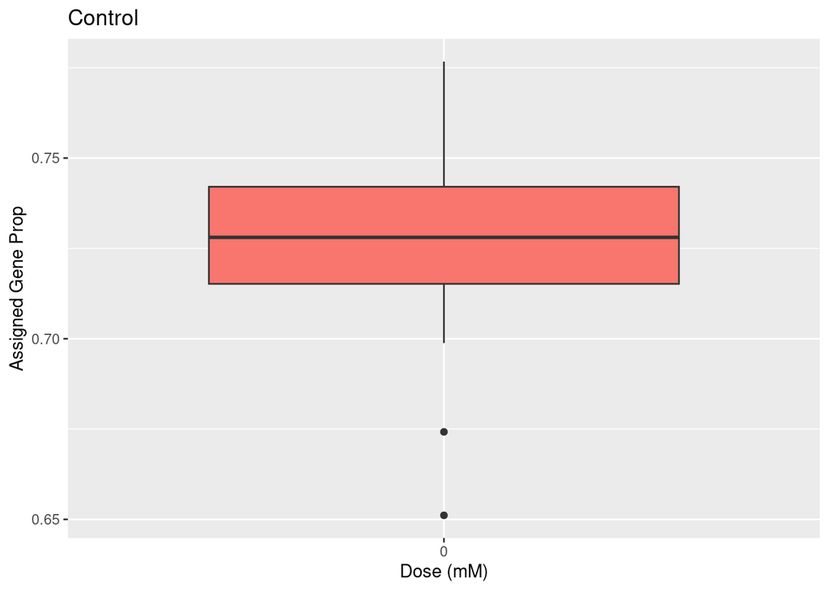

```r
## Y ahora en los datos del grupo control
ggplot(data=as.data.frame(colData(control)), aes(x=factor(sra_attribute.dose), y=assigned_gene_prob)) +
  geom_boxplot(aes(fill = factor(sra_attribute.dose))) +
  theme(legend.position="none") +
  ylab("Assigned Gene Prop") +
  xlab("Dose (mM)") +
  ggtitle("Control")
```

# Modelo Estadístico

```r
## Computamos el modelo estadístico
mod <- model.matrix(~ sra_attribute.agent + sra_attribute.cell_line + sra_attribute.dose + sra_attribute.time + assigned_gene_prob, data = colData(rse_gene_SRP107565))
colnames(mod)
```

```
##  [1] "(Intercept)"                    "sra_attribute.agentcontrol"
##  [3] "sra_attribute.agentpalbociclib" "sra_attribute.agentribociclib"
##  [5] "sra_attribute.cell_lineBT549"   "sra_attribute.cell_lineHCC1419"
##  [7] "sra_attribute.cell_lineHCC1806" "sra_attribute.cell_lineHS578T"
##  [9] "sra_attribute.cell_lineMCF7"    "sra_attribute.cell_lineT47D"
## [11] "sra_attribute.dose"             "sra_attribute.time"
## [13] "assigned_gene_prob"
```

# Análisis diferencial

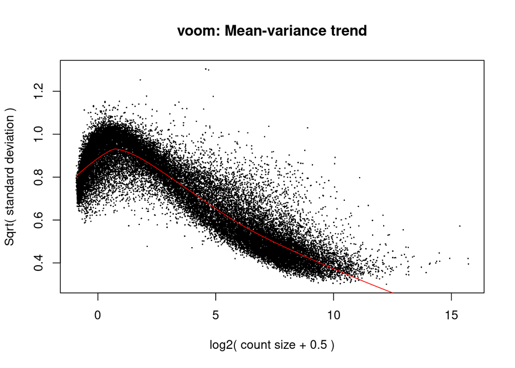

```r
## Usamos lima para el análisis de expresión diferencial
library("limma")
vGene <- voom(dge, mod, plot = TRUE)
```

```r
eb_results <- eBayes(lmFit(vGene))

de_results <- topTable(
    eb_results,
    coef = 2,
    number = nrow(rse_gene_SRP107565),
    sort.by = "none"
)
## Vemos las dimensiones de los genes diferencialmente diferenciados
dim(de_results)
```

```
## [1] 34554    16
```

```r
## Visualizamos los primero 6 que nos arroja el análisis diferencial.
head(de_results)
```

|  | source | type | bp_length | phase | gene_id | gene_type | gene_name | level | havana_gene | tag | logFC | AveExpr | t | P.Value | adj.P.Val | B |
| --- | --- | --- | --- | --- | --- | --- | --- | --- | --- | --- | --- | --- | --- | --- | --- | --- |
| ENSG00000223972.5 | HAVANA | gene | 1735 | NA | ENSG00000223972.5 | transcribed_unprocessed_pseudogene | DDX11L1 | 2 | OTTHUMG00000000961.2 | NA | -0.22224069 | -0.9740932 | -1.1135364 | 0.266803225 | 0.470299438 | -5.183188 |
| ENSG00000278267.1 | ENSEMBL | gene | 68 | NA | ENSG00000278267.1 | miRNA | MIR6859-1 | 3 | NA | NA | 0.13569704 | -2.7381082 | 0.6981855 | 0.485865233 | 0.677650581 | -5.492235 |
| ENSG00000227232.5 | HAVANA | gene | 1351 | NA | ENSG00000227232.5 | unprocessed_pseudogene | WASH7P | 2 | OTTHUMG00000000958.1 | NA | -0.09267525 | 2.2841239 | -1.2105448 | 0.227486419 | 0.424024475 | -5.490361 |
| ENSG00000243485.5 | HAVANA | gene | 1021 | NA | ENSG00000243485.5 | lincRNA | MIR1302-2HG | 2 | OTTHUMG00000000959.2 | ncRNA_host | -0.34962346 | -3.0084632 | -1.9160885 | 0.056767604 | 0.157339198 | -4.117961 |
| ENSG00000239945.1 | HAVANA | gene | 1319 | NA | ENSG00000239945.1 | lincRNA | RP11-34P13.8 | 2 | OTTHUMG00000001097.2 | overlapping_locus | -0.34496311 | -2.7396414 | -1.6164423 | 0.107561535 | 0.251543818 | -4.539688 |
| ENSG00000238009.6 | HAVANA | gene | 3726 | NA | ENSG00000238009.6 | lincRNA | RP11-34P13.7 | 2 | OTTHUMG00000001096.2 | overlapping_locus | -0.67694015 | -1.2848010 | -3.1729524 | 0.001744902 | 0.009008417 | -1.325216 |

```r
## Vemos cuantos genes diferencialmente expresados con un p-valor menor a 0.05 tenemos
table(de_results$adj.P.Val < 0.05)
```

```
##
## FALSE  TRUE
## 25367  9187
```

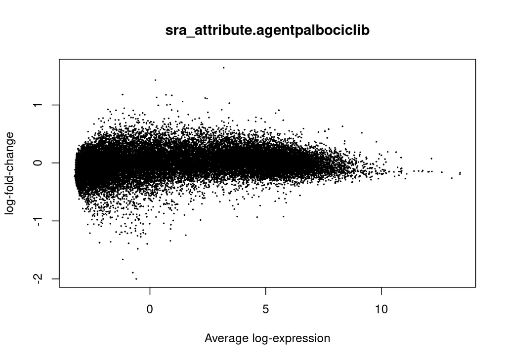

```r
## Graficamos el modelo estadístico con las variables correspondientes a tratamiento
plotMA(eb_results, coef = 3)
```

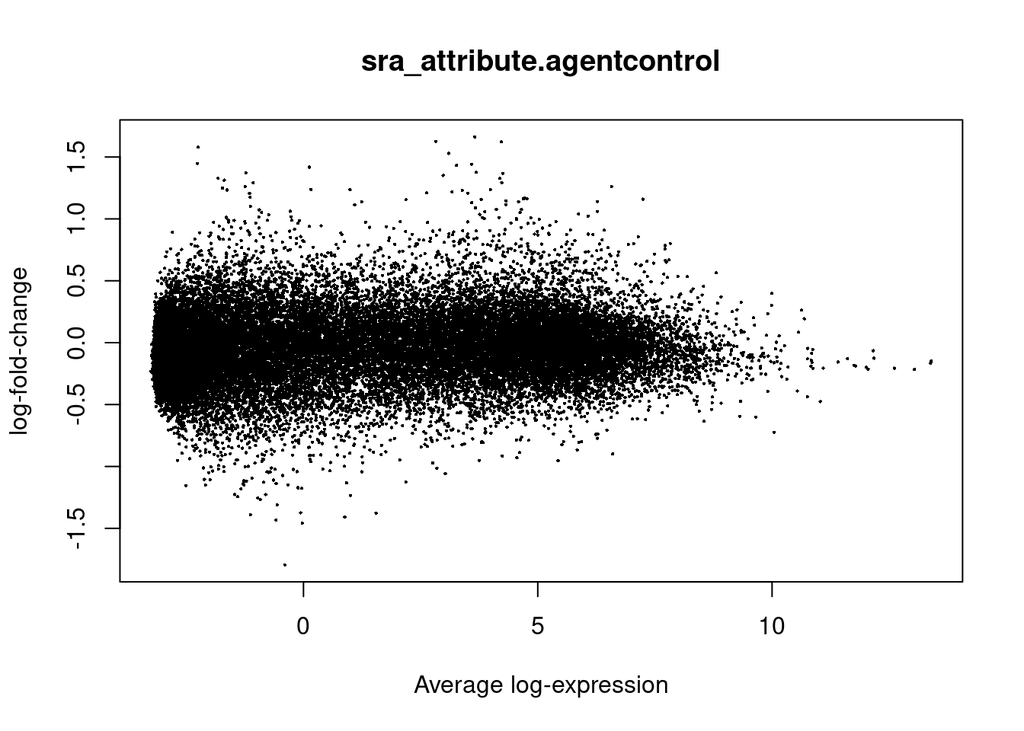

```r
plotMA(eb_results, coef = 2)
```

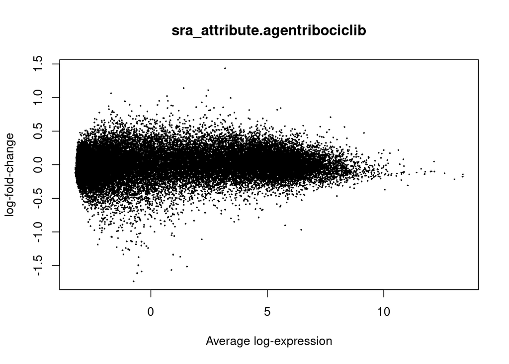

```r
plotMA(eb_results, coef = 4)
```

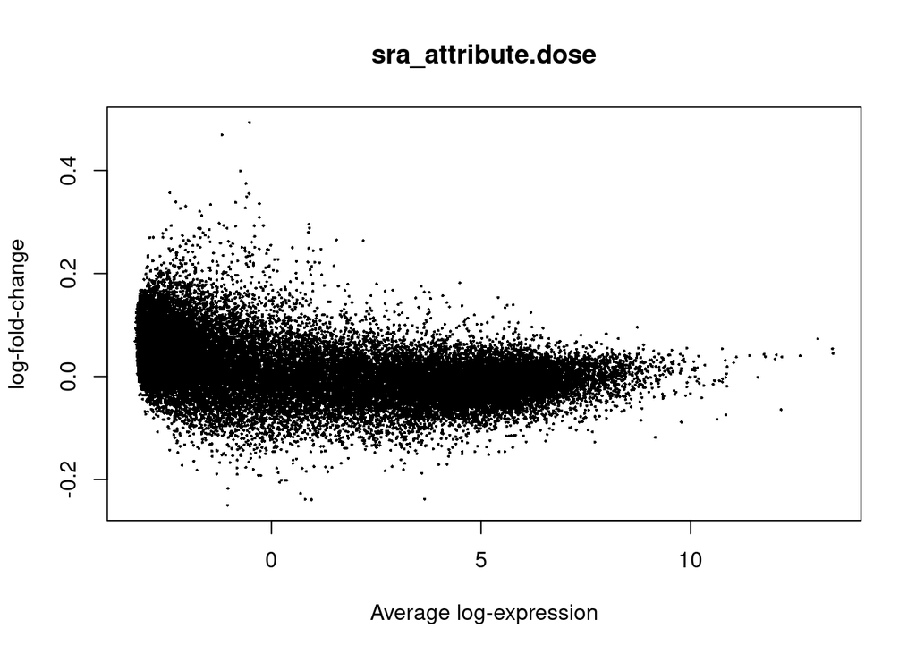

```r
## Graficamos por dosis y por tiempo
plotMA(eb_results, coef = 11)
```

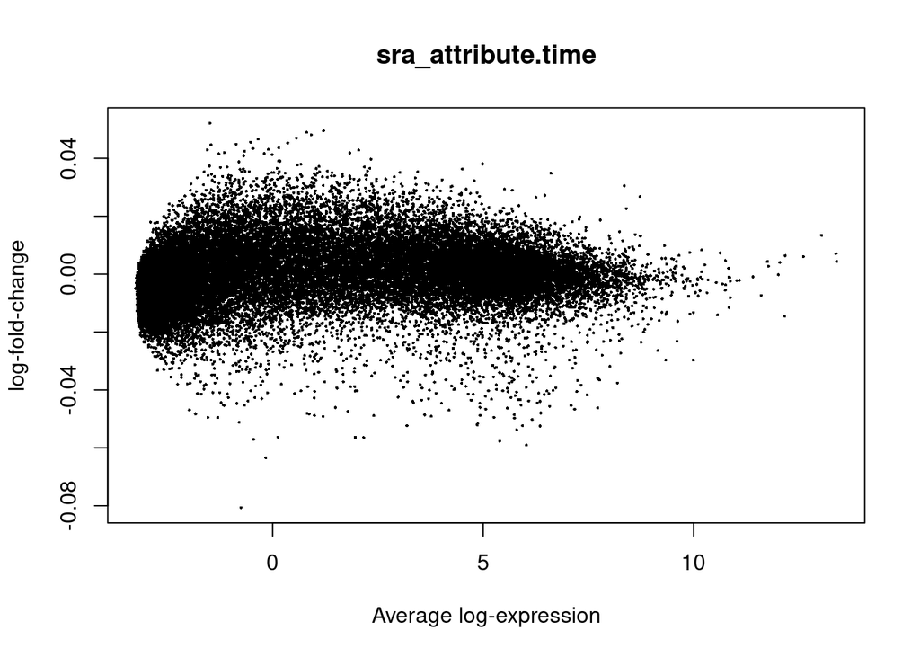

```r
plotMA(eb_results, coef = 12)
```

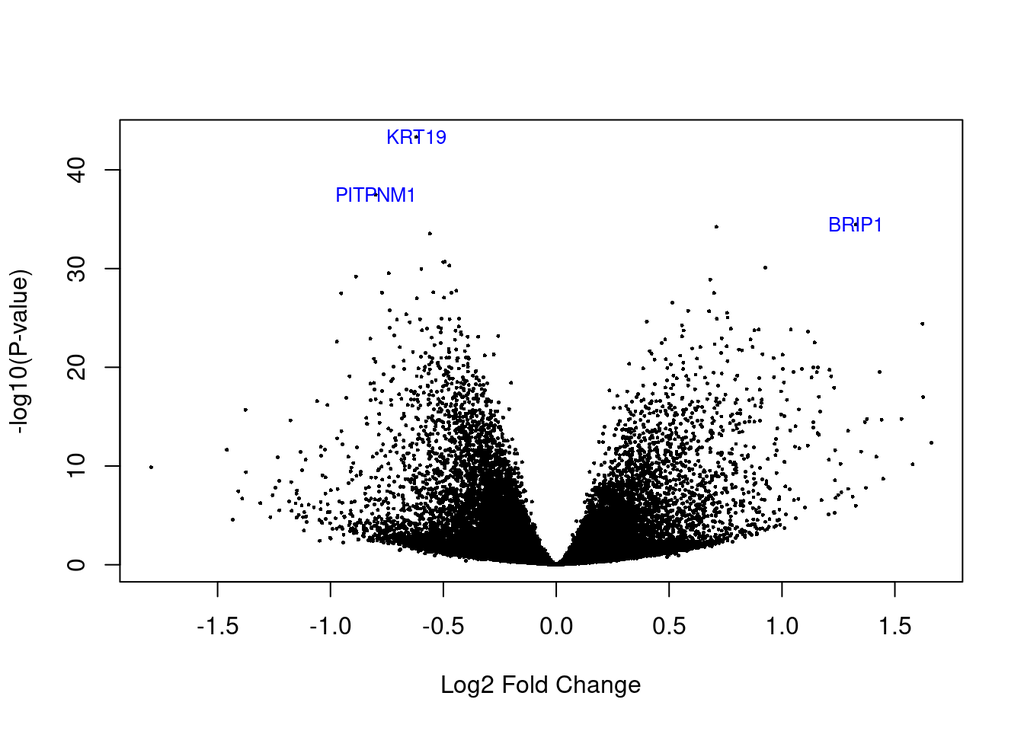

```r
## Graficamos los volcanoplot por variable de tratamiento
volcanoplot(eb_results, coef = 2, highlight = 3, names = de_results$gene_name)
```

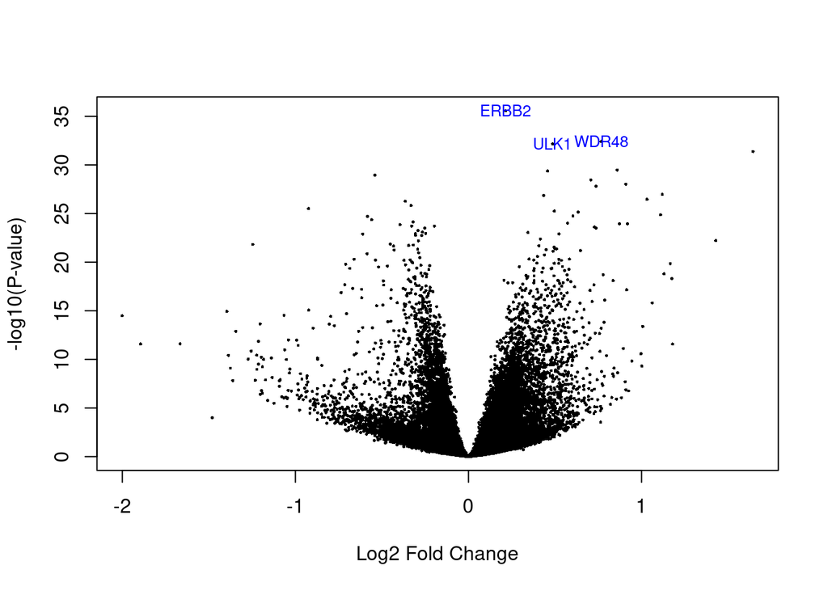

```r
volcanoplot(eb_results, coef = 3, highlight = 3, names = de_results$gene_name) #palbociclib
```

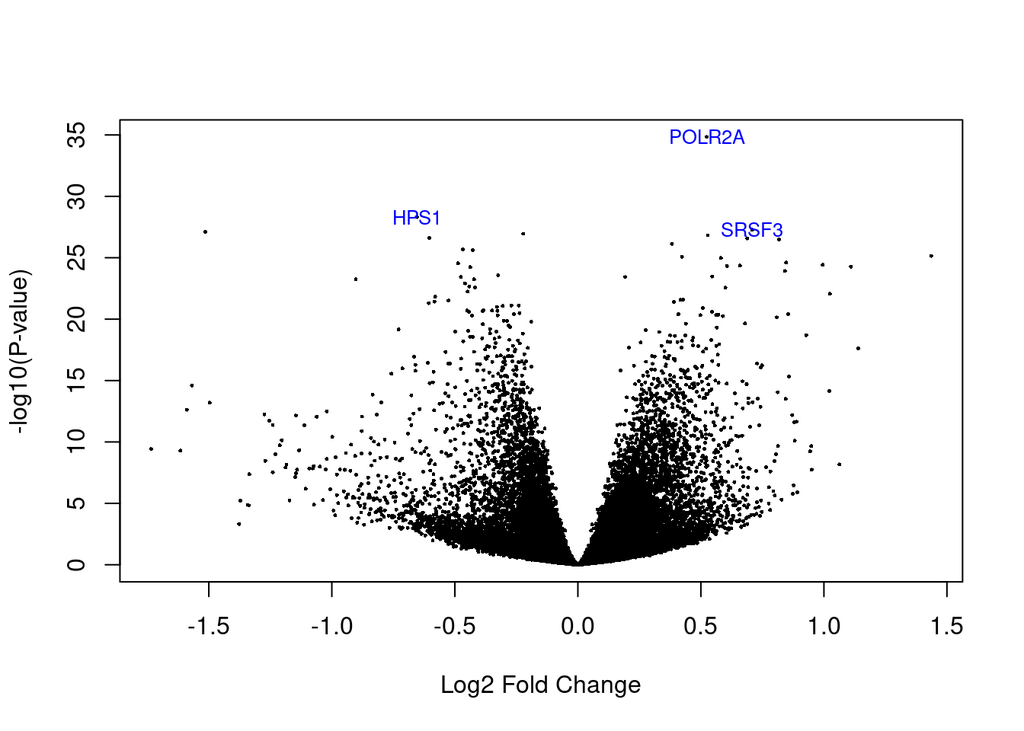

```r
volcanoplot(eb_results, coef = 4, highlight = 3, names = de_results$gene_name)
```

```r
## Buscando los DEGs
de_results[de_results$gene_name %in% c("ERBB2", "ULK1", "WDR48"), ]
```

|  | source | type | bp_length | phase | gene_id | gene_type | gene_name | level | havana_gene | tag | logFC | AveExpr | t | P.Value | adj.P.Val | B |
| --- | --- | --- | --- | --- | --- | --- | --- | --- | --- | --- | --- | --- | --- | --- | --- | --- |
| ENSG00000177169.9 | HAVANA | gene | 7608 | NA | ENSG00000177169.9 | protein_coding | ULK1 | 2 | OTTHUMG00000168052.5 | overlapping_locus | -0.08986727 | 5.511966 | -2.048306 | 4.182531e-02 | 1.243959e-01 | -5.002449 |
| ENSG00000141736.13 | HAVANA | gene | 10321 | NA | ENSG00000141736.13 | protein_coding | ERBB2 | 1 | OTTHUMG00000179300.3 | ncRNA_host | -0.20006296 | 7.445300 | -9.925076 | 3.699607e-19 | 6.589495e-17 | 31.947908 |
| ENSG00000114742.13 | HAVANA | gene | 7488 | NA | ENSG00000114742.13 | protein_coding | WDR48 | 1 | OTTHUMG00000155972.6 | NA | 0.57456403 | 4.810190 | 8.183269 | 3.075217e-14 | 1.602731e-12 | 21.855543 |

Ahora podemos revisar los top 50 diferencialmente expresados.

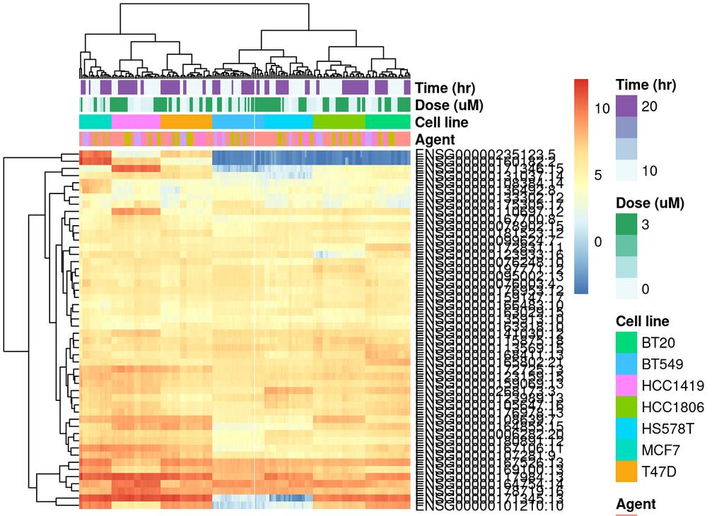

```r
## Extraer valores de los primeros cincuenta genes
heatmap <- vGene$E[rank(de_results$adj.P.Val) <= 50, ]

## Creemos una tabla con las muestras
df_heatmap <- as.data.frame(colData(rse_gene_SRP107565)[, c("sra_attribute.agent", "sra_attribute.cell_line", "sra_attribute.dose", "sra_attribute.time")])
colnames(df_heatmap) <- c("Agent", "Cell line", "Dose (uM)", "Time (hr)")

## Heatmap
library("pheatmap")
pheatmap(
    heatmap,
    cluster_rows = TRUE,
    cluster_cols = TRUE,
    show_rownames = TRUE,
    show_colnames = FALSE,
    annotation_col = df_heatmap
)
```

El heatmap no nos deja ver mucha diferencia entre las muestras, pero se puede llegar a ver algunas diferencias entre tipos celulares, ya que se van dividiendo algunas de las columnas por línea celular.

Ahora vamos a hacer un multidimensional scaling.

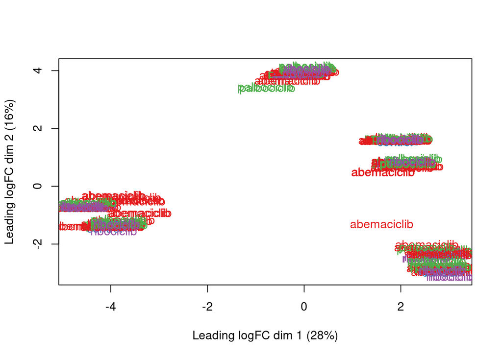

```r
## Para colores
library("RColorBrewer")

## Convirtiendo los grupos de tratamiento
col.group <- df_heatmap$Agent
levels(col.group) <- brewer.pal(nlevels(col.group), "Set1")
col.group <- as.character(col.group)

## MDS por grupos de tratamiento
plotMDS(vGene$E, labels = df_heatmap$Agent, col = col.group)
```

```r
## Vemos genes estadísticamente significativos asociados al tratamiento de abemaciclib.
head(vGene[,rse_gene_SRP107565$sra_attribute.agent == "abemaciclib"]$genes[rank(de_results$adj.P.Val) <= 50, ])
```

|  | source | type | bp_length | phase | gene_id | gene_type | gene_name | level | havana_gene | tag |
| --- | --- | --- | --- | --- | --- | --- | --- | --- | --- | --- |
| ENSG00000197771.12 | HAVANA | gene | 6000 | NA | ENSG00000197771.12 | protein_coding | MCMBP | 2 | OTTHUMG00000019159.4 | NA |
| ENSG00000078902.15 | HAVANA | gene | 5983 | NA | ENSG00000078902.15 | protein_coding | TOLLIP | 1 | OTTHUMG00000133333.5 | NA |
| ENSG00000117984.13 | HAVANA | gene | 3126 | NA | ENSG00000117984.13 | protein_coding | CTSD | 1 | OTTHUMG00000044760.23 | overlapping_locus |
| ENSG00000166483.10 | HAVANA | gene | 9239 | NA | ENSG00000166483.10 | protein_coding | WEE1 | 1 | OTTHUMG00000165863.3 | ncRNA_host |
| ENSG00000172725.13 | HAVANA | gene | 5327 | NA | ENSG00000172725.13 | protein_coding | CORO1B | 2 | OTTHUMG00000167775.3 | overlapping_locus |
| ENSG00000110697.12 | HAVANA | gene | 6449 | NA | ENSG00000110697.12 | protein_coding | PITPNM1 | 1 | OTTHUMG00000167675.3 | NA |

# Conclusiones

Los datos de expresión que sacamos del dataset estudiado nos dicen que hay una mayor carga de expresión dieferencial entre lineas celulares. Esto es lógico puesto a que cada línea celular expresa un subtipo diferente de cáncer de mama y por consiguiente debería haber expresiones de distintos genes a distintos niveles. Esto fue lo que se hizo más evidente en la gráfica de heatmap. También observamos que existen genes que están expresados negativamente en al menos cuatro de las siete líneas celulares que se usaron, independientemente del tratamiento que se usó (ENSG00000235123.5 y ENSG00000160182.2). Por el contrario hay genes que se dieferenciaron mucho positivamente (ENSG00000171345.13 y ENSG00000101210.10) en todas las líneas celulares, menos en HS578T y BT549.

HS578T es un alínea celular perteneciente a cáncer de mama triple negativo que tiene una deleción homocigota una CDKN2A que podría hablarnos de eficiencia de los inhibidores de ciclina, puesto a que no solamente tiene la deleción en CDKN2A, sino que tal vez su mecanismo de compensación con otras ciclinas también está siendo afectado.

BT549 también es de cáncer de mama triple negativo, esto nos puede decir que los inhibidores de ciclinas sirven en cánceres agresivos y avanzados como el raro pero presente triple negativo en comparación con los estrógeno positivo.